# Analysis & visualization

Mark Scheuerell

12 February 2021

# Background

Analysis and reporting are a large and important part of the data science process. Communicating what you did and how you did it is critical to a reproducible workflow.

# Example analysis

Here is an example of an exploratory analysis based on a re-examination of some count data on seastars obtained before and after a wasting syndrome. The original analysis was conducted and published by [Schultz (2016)](https://peerj.com/articles/1980/). Here is the abstract from their paper.

> Echinoderm population collapses, driven by disease outbreaks and climatic events, may be important drivers of population dynamics, ecological shifts and biodiversity. The northeast Pacific recently experienced a mass mortality of sea stars. In Howe Sound, British Columbia, the sunflower star *Pycnopodia helianthoides*—a previously abundant predator of bottom-dwelling invertebrates—began to show signs of a wasting syndrome in early September 2013, and dense aggregations disappeared from many sites in a matter of weeks. Here, we assess changes in subtidal community composition by comparing the abundance of fish, invertebrates and macroalgae at 20 sites in Howe Sound before and after the 2013 sea star mortality to evaluate evidence for a trophic cascade. We observed changes in the abundance of several species after the sea star mortality, most notably a four-fold increase in the number of green sea urchins, *Strongylocentrotus droebachiensis*, and a significant decline in kelp cover, which are together consistent with a trophic cascade. Qualitative data on the abundance of sunflower stars and green urchins from a citizen science database show that the patterns of echinoderm abundance detected at our study sites reflected wider local trends. The trophic cascade evident at the scale of Howe Sound was observed at half of the study sites. It remains unclear whether the urchin response was triggered directly, via a reduction in urchin mortality, or indirectly, via a shift in urchin distribution into areas previously occupied by the predatory sea stars. Understanding the ecological implications of sudden and extreme population declines may further elucidate the role of echinoderms in temperate seas, and provide insight into the resilience of marine ecosystems to biological disturbances.

## Main results

Here is Figure 3 from Schultz et al. (2016), which shows the mean counts of organisms before and after the wasting event. They used a barplot with symmetrical errors bars based on a (in my opinion) flawed model for counts. That is, the error bars are symmetric around the means, which suggests that they might indeed observe negative counts.

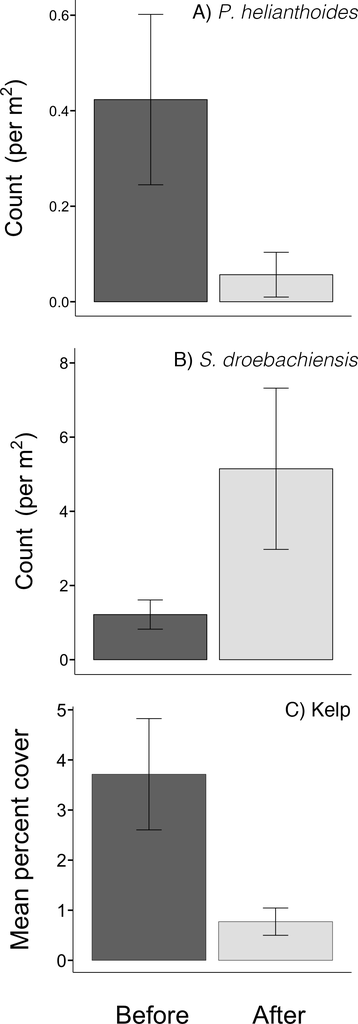

**Figure 3**. Mean abundance (per m2) of (A) sunflower stars and (B) green sea urchins, and (C) percent cover of kelp on rocky reefs in Howe Sound, British Columbia, on 80 transects before and after the mass mortality of sea stars in 2013. Error bars represent standard error. The dominant kelp was the sea colander kelp, *Agarum fimbriatum*.

## Models for count data

The before/after comparison of organism densities in Schultz et al. is based upon discrete counts of individuals. Thus, we should really consider statistical distributions that reflect the true nature of the data rather than trying to transform the data and analyze it with a continuous distribution (e.g., Gaussian).

### Poisson distribution

The Poisson distribution is one of the most common ways to model count data because it has only one parameter to estimate (i.e., the mean are the variance are equal). If we expect, on average, $\lambda_t$ individuals m<sup>-2</sup> at time $t$, and we sample a total of $A$ m<sup>2</sup>, then each of $i$ counts during that period ($c_{i,t}$) would reflect the following Poisson process:

$$c_{i,t} \sim \text{Poisson}(\lambda_t A).$$

Because the rate constant $\lambda_t$ must be greater than zero, one generally assumes a log-link whereby

$$\log(\lambda_t) \sim \text{Normal}(\mu, \sigma^2).$$

### Negative binomial distribution

An alternatve to the Poisson is the negative binomial distribution, which has an additional parameter to account for overdispersion in the data (i.e. the mean and variance are not equal). Specifically,

$$c_{i,t} \sim \text{NegBin}(p, r).$$

The shape (dispersion) parameter $r$ must be greater than zero and can be modeled with a uniform distribution, such that

$$r \sim \text{Uniform}(0, U)$$

The probability parameter $p$ can be written in terms of $r$ and the underlying mean $\lambda_t A$, whereby

$$p = \frac{r}{r + \lambda_t A}$$

$$\sigma^2 = \lambda_t A + \frac{(\lambda_t A)^2}{r},$$
such that the variance converges to the mean as $r \rightarrow \infty$, and the negative binomial converges to the Poisson.

#### Aside on equations

The above equations are written in **LaTeX** form, which can be a bit tricky to figure out when you’re first learning. There is a neat package called [equatiomatic](https://datalorax.github.io/equatiomatic/index.html), which will take the results from a fitted model in **R** and transform it into the corresponding **LaTeX** code. For example, this code fits a simple linear regression model from the `mtcars` dataset and then writes the equation.

```r
library(equatiomatic)

## Fit a simple linear regression model
model_fit <- lm(mpg ~ cyl + disp, mtcars)

## Give the results to extract_eq
extract_eq(model_fit)

## raw result
## $$
## \operatorname{mpg} = \alpha + \beta_{1}(\operatorname{cyl}) + \beta_{2}(\operatorname{disp}) + \epsilon
## $$
```

$$\operatorname{mpg} = \alpha + \beta_{1}(\operatorname{cyl}) + \beta_{2}(\operatorname{disp}) + \epsilon$$

## Requirements

I rely on a number of packages for reading, munging, and plotting the data, which include:

- [Jenny Bryan’s](https://github.com/jennybc) [**readxl**](http://readxl.tidyverse.org/);
- several from [Hadley Wickham’s](https://github.com/hadley) [**tidyverse**](http://www.tidyverse.org/);
- [Thomas Lin Pederson’s](https://github.com/thomasp85) [**patchwork**](https://github.com/thomasp85/patchwork).

In addition to some frequentist approaches, I also show different options for Bayesian model fitting using the following software and packages:

- [**JAGS**](http://mcmc-jags.sourceforge.net/) and the [**R2jags**](https://cran.r-project.org/web/packages/R2jags/index.html) package;

```r
## for reading data
library(readxl)
library(readr)
## for data munging
library(dplyr)
library(tidyr)
## for plotting
library(ggplot2)
library(patchwork)
## for model fitting
library(R2jags)
```

## Data

Schultz et al. were very considerate in posting the data they used for the analyses and figures in their paper. Those data are available in MS Excel format from *PeerJ*’s server in a file called [Schultz_data_ver2.xlsx](https://peerj.com/articles/1980/#supp-1).

### Step 1: Convert Excel workbook to csv files

The [code](https://peerj.com/articles/1980/#supp-2) provided by the authors works with various data files in .csv format, so I begin by extracting those from the .xlsx file.

```r
## data directory
data_dir <- here::here("lectures", "week_06", "data")
## original data file
orig_data <- file.path(data_dir, "Schultz_data_ver2.xlsx")
## worksheets in notebook
sht_names <- excel_sheets(orig_data)
## convert worksheets to csv
if(length(list.files(data_dir, "csv")) == 0) {
  for(i in sht_names) {
    orig_data %>% read_xlsx(sheet = i) %>%
      write_csv(file = file.path(data_dir, i))
  }
}
```

### Step 2: Load count data

The data arise from a series of samples before and after the seastar wasting event, with counts of various species obtained within 0.25 m<sup>2</sup> quadrats at 15 locations along each of 4 transects at 20 different sites. The counts reported by the authors have been summed across all of the 15 quadrats for each transect/site combination, so the data frame has a total of (2 periods) x (4 transects) x (20 sites) = 160 rows.

```r
## read count data
counts <- read_csv(file.path(data_dir, "transectcounts.csv"))
colnames(counts)
```

```
##  [1] "ssws"                "site"                "transect"
##  [4] "california.cucumber" "dungeness.crab"      "green.urchin"
##  [7] "grunt.sculpin"       "longfin.sculpin"     "misc.crab"
## [10] "octopus"             "orange.cup.coral"    "red.rock.crab"
## [13] "red.urchin"          "sailfin.sculpin"     "scalyhead.sculpin"
## [16] "sculpin"             "shrimp"              "spot.prawn"
## [19] "squat.lobster"       "sunflower.star"      "white.urchin"
```

```r
## split out before/after counts of sunflower stars
## wide format
stars_wide <- counts %>%
  select(ssws, transect, sunflower.star) %>%
  spread(ssws, value = sunflower.star)  %>%
  select(-transect)
## tidy format
stars_tidy <- stars_wide %>%
  gather(key = time, value = count)
```

### Step 3: Plot the data

These data contain a lot of zeros, so visualization can be a bit tricky. Here are two options: a jittered dot plot (left) and violin plot (right). These are rough *exploratory* figures.

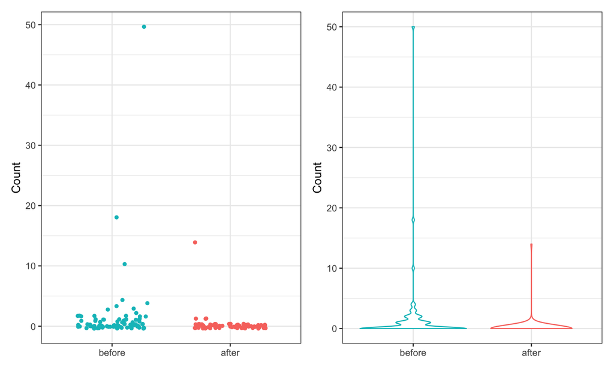

```r
## base plot
pp <- ggplot(stars_tidy, aes(x=time, y=count, color=time))
## jittered dotplot
p1 <- pp + geom_jitter(shape=16, position=position_jitter(0.3)) + theme_bw()
## violin plot
p2 <- pp + geom_violin() + theme_bw()
## combine plots
p1 + p2 &
  theme(legend.position="none") &
  scale_x_discrete(limits=c("before","after")) &
  labs(x = "", y = "Count")
```

## Analyses

### Poisson models

We need to define the total survey area, so we can use it as an offset in our statistical models.

```r
## total survey area in m^2
area <- 3.75
```

Here’s the **JAGS** code for fitting a Poisson distribution to the data.

```r
## define Poisson model in JAGS
cat("

data {
  N <- dim(stars_wide);
}

model {
  ## PRIORS
  ln_lambda_bef ~ dnorm(0,0.01);
  ln_lambda_aft ~ dnorm(0,0.01);
  ## DERIVED PARAMS
  lambda_bef <- exp(ln_lambda_bef);
  lambda_aft <- exp(ln_lambda_aft);
  ## LIKELIHOOD
  for(i in 1:N[1]) {
    stars_wide[i,1] ~ dpois(lambda_aft * area);
    stars_wide[i,2] ~ dpois(lambda_bef * area);
  }
}

", file="poisson_glm.txt") ## end model description

## data to pass to JAGS
dat_jags <- c("stars_wide", "area")
## model params for JAGS to return
par_jags <- c("lambda_bef","lambda_aft")
## MCMC control params
mcmc_chains <- 4
mcmc_length <- 2e4
mcmc_burn <- 1e4
mcmc_thin <- 20
## total number of MCMC samples
mcmc_samp <- (mcmc_length-mcmc_burn)*mcmc_chains/mcmc_thin
## list of model info for JAGS
mod_jags <- list(data = dat_jags,
                 model.file = "poisson_glm.txt",
                 parameters.to.save = par_jags,
                 n.chains = as.integer(mcmc_chains),
                 n.iter = as.integer(mcmc_length),
                 n.burnin = as.integer(mcmc_burn),
                 n.thin = as.integer(mcmc_thin))
## fit model
po_fit_jags <- do.call(jags.parallel, mod_jags)
```

### Examine parameter estimates

The first thing we can do is examine a summary table of the posterior samples.

```r
print(po_fit_jags)
```

```
## Inference for Bugs model at "poisson_glm.txt", fit using jags,
##  4 chains, each with 20000 iterations (first 10000 discarded), n.thin = 20
##  n.sims = 2000 iterations saved
##            mu.vect sd.vect    2.5%     25%     50%     75%   97.5%  Rhat n.eff
## lambda_aft   0.057   0.014   0.033   0.047   0.056   0.065   0.086 1.000  2000
## lambda_bef   0.423   0.038   0.354   0.397   0.423   0.448   0.501 1.000  2000
## deviance   710.166   2.017 708.212 708.755 709.554 710.930 715.228 1.006  1800
##
## For each parameter, n.eff is a crude measure of effective sample size,
## and Rhat is the potential scale reduction factor (at convergence, Rhat=1).
##
## DIC info (using the rule, pD = var(deviance)/2)
## pD = 2.0 and DIC = 712.2
## DIC is an estimate of expected predictive error (lower deviance is better).
```

Visual summaries of the results can also be useful. Here are histograms of the posterior samples (left) and a summary of the median and 95% credible interval of the posterior samples (right).

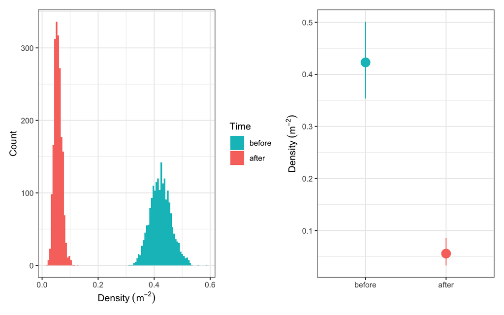

```r
## gather posteriors samples
pdat <- data.frame(Time = rep(c("before","after"), ea=mcmc_samp),
                   samples = c(po_fit_jags$BUGSoutput$sims.list$lambda_bef,
                               po_fit_jags$BUGSoutput$sims.list$lambda_aft))
## summary of posteriors
pdat2 <- pdat %>%
  group_by(Time) %>%
  summarize(lo = quantile(samples, 0.025),
            med = quantile(samples, 0.5),
            hi = quantile(samples, 0.975))
## histogram of posteriors
p1 <- ggplot(pdat, aes(samples, fill = Time)) +
  theme_bw() +
  geom_histogram(bins = 100) +
  guides(fill = guide_legend(reverse=TRUE)) +
  labs(x = expression(Density~(m^-2)), y = "Count")
p2 <- ggplot(pdat2, aes(x=Time, y=med, color=Time)) +
  theme_bw() +
  geom_point(aes(size=1.5)) +
  geom_errorbar(aes(ymin=lo, ymax=hi), width=0) +
  scale_x_discrete(limits=c("before","after")) +
  xlab("") +
  ylab(expression(Density~(m^-2))) +
  theme(legend.position="none")
p1 + p2
```

### Negative binomial models

Here is the **JAGS** code for fitting a negative binomial model to the data.

```r
## define negative binomial model in JAGS
cat("

data {
  N <- dim(stars_wide);
}

model {
  ## PRIORS
  r_bef ~ dnorm(0,0.01) T(0,);
  r_aft ~ dnorm(0,0.01) T(0,);
  lambda_bef ~ dnorm(0,0.1) T(0,);
  lambda_aft ~ dnorm(0,0.1) T(0,);
  ## DERIVED PARAMS
  mu_bef <- lambda_bef * area;
  mu_aft <- lambda_aft * area;
  p_aft <- r_aft / (r_aft + mu_aft);
  p_bef <- r_bef / (r_bef + mu_bef);
  mean_bef <- r_bef * (1 - p_bef) / p_bef;
  mean_aft <- r_aft * (1 - p_aft) / p_aft;
  var_bef <- mean_bef / p_bef;
  var_aft <- mean_aft / p_aft;
  ## LIKELIHOOD
  for(i in 1:N[1]) {
    stars_wide[i,1] ~ dnegbin(p_aft, r_aft);
    stars_wide[i,2] ~ dnegbin(p_bef, r_bef);
  }
}

", file="negbin_glm.txt") ## end model description

## update model params for JAGS to return
par_jags <- c("lambda_bef","mean_bef","var_bef","lambda_aft","mean_aft","var_aft")

## update list of model info for JAGS
mod_jags$model.file <-"negbin_glm.txt"
mod_jags$parameters.to.save <- par_jags

## fit model
nb_fit_jags <- do.call(jags.parallel, mod_jags)
```

### Examine parameter estimates

Again we can examine a summary table of the parameter estimates. Notice that in this case, we also have estimates for mean and variance of the density of stars per 3.75 m<sup>2</sup>.

```r
print(nb_fit_jags)
```

```
## Inference for Bugs model at "negbin_glm.txt", fit using jags,
##  4 chains, each with 20000 iterations (first 10000 discarded), n.thin = 20
##  n.sims = 2000 iterations saved
##             mu.vect   sd.vect    2.5%     25%     50%     75%     97.5%  Rhat
## lambda_aft    0.723     1.126   0.030   0.096   0.250   0.800     4.198 1.001
## lambda_bef    0.484     0.138   0.285   0.384   0.460   0.556     0.818 1.001
## mean_aft      2.711     4.221   0.113   0.360   0.938   3.001    15.744 1.001
## mean_bef      1.815     0.518   1.067   1.439   1.727   2.086     3.067 1.001
## var_aft    2964.377 10679.746   0.549   5.559  45.708 733.358 29382.594 1.001
## var_bef      18.377    13.227   5.835  10.245  14.553  22.134    53.578 1.001
## deviance    287.547     3.393 282.628 285.075 287.167 289.418   295.362 1.001
##            n.eff
## lambda_aft  2000
## lambda_bef  2000
## mean_aft    2000
## mean_bef    2000
## var_aft     2000
## var_bef     1700
## deviance    2000
##
## For each parameter, n.eff is a crude measure of effective sample size,
## and Rhat is the potential scale reduction factor (at convergence, Rhat=1).
##
## DIC info (using the rule, pD = var(deviance)/2)
## pD = 5.8 and DIC = 293.3
## DIC is an estimate of expected predictive error (lower deviance is better).
```

This time I use a frequency plot instead of a histogram because the overlap in the distributions makes them hard to discern otherwise.

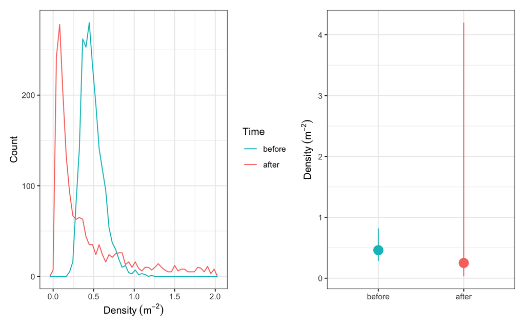

```r
## gather posteriors samples
pdat <- data.frame(Time = rep(c("before","after"), ea=mcmc_samp),
                   samples = c(nb_fit_jags$BUGSoutput$sims.list$lambda_bef,
                               nb_fit_jags$BUGSoutput$sims.list$lambda_aft))
## summary of posteriors
pdat2 <- pdat %>%
  group_by(Time) %>%
  summarize(lo = quantile(samples, 0.025),
            med = quantile(samples, 0.5),
            hi = quantile(samples, 0.975))
## trim away big values for histogram
pdat <- pdat %>%
  filter(samples <= 2)
## histogram of posteriors
p1 <- ggplot(pdat, aes(samples, color = Time)) +
  theme_bw() +
  geom_freqpoly(bins = 50) +
  guides(color = guide_legend(reverse=TRUE)) +
  labs(x = expression(Density~(m^-2)), y = "Count")
p2 <- ggplot(pdat2, aes(x=Time, y=med, color=Time)) +
  theme_bw() +
  geom_point(aes(size=1.5)) +
  geom_errorbar(aes(ymin=lo, ymax=hi), width=0) +
  scale_x_discrete(limits=c("before","after")) +
  labs(x = "", y = expression(Density~(m^-2))) +
  theme(legend.position="none")
p1 + p2
```

# Graphic design concepts

In the world of graphic design, Edward Tufte has long been considered the authoritative source of do’s and don’ts. He has a very popular book called [*The Visual Display of Quantitative Information*](https://www.edwardtufte.com/tufte/books_vdqi), which is worth perusing. I can also recommend Lukasz Piwek’s wonderful online treatment of some Tufte-esque designs, [Tufte in R](http://motioninsocial.com/tufte/), which include options for making plots in both **base graphics** and **ggplot**. If you’d like to take a much deeper dive into plot design, I suggest you consider taking [Trevor Branch](https://fish.uw.edu/faculty/trevor-branch/)’s course [FISH 554: Beautiful Graphics in R](https://canvas.uw.edu/courses/1355148/assignments/syllabus).

## Kinds of figures

If you’re interested in exploring the different kinds of plots/figures available for different data types, I highly recommend the [**R Graph Gallery**](https://www.r-graph-gallery.com/). You can click through the examples and see all of the code necessary to produce them, often via **base graphics** or **ggplot2**.

## Exploratory vs expository figures

Check out [this wonderful vignette](http://jtleek.com/ads2020/week-10.html#creating-expository-graphs) by Jeff Leek of transitioning from exploratory to expository figures.

## Color palettes

Color choice in figures is a combination of art and science. You’d like your figures to visually appeal to a wide audience, which includes people with visual disabilities. There are a variety of **R** packages that focus exclusively on color schemes. For example,

- David Miller’s [**Beyonce**](https://github.com/dill/beyonce)
- Jake Lawlor’s [**PNWColor**](https://github.com/jakelawlor/PNWColors)
- Cianna Bedford-Petersen’s [**2021 Inauguration**](https://github.com/ciannabp/inauguration)

However, these are not necessarily “colorblind safe”. If you want some colorblind safe palettes, then I suggest you consider the

- [Viridis palettes](https://cran.r-project.org/web/packages/viridis/vignettes/intro-to-viridis.html)

If you’d like to test what an image will look like to people with different forms of colorblindness, you can use the

- [Color Blindness Simulator](https://www.color-blindness.com/coblis-color-blindness-simulator/)

to upload an image and it will transform it into the appropriate hues.

### Color selectors

There are some nice online tools to help you choose color palettes. One of the most popular is

- [Colorbrewer](https://colorbrewer2.org/)

which allows you to choose from *sequential* or *diverging* palettes, and even screen for those that are colorblind safe. Another good option is

- [Color Palette Helper](https://gka.github.io/palettes)

which allows you to specify beginning and end colors and the number of steps you’d like in between.

#### Diverging palettes

Diverging palettes should be used when there is a clear midpoint in the data, such that values above or below the midpoint take on different shades of a unique hue.

## Pie charts

Although the use of pie charts is very common, there have been numerous cognitive studies that suggest people actually have a hard time discerning how the area of the various slices relates to actual percentages. If you feel really tempted to use a pie chart, ask yourself whether or not the data would be better displayed in a table.

### Waffleplots

So-called *waffle plots* offer an alternative to pie charts. Waffle plots are square or rectangular representations of proportion data. Here’s an example of some waffle plots created with Bob Rudis’ [**waffle** package](https://github.com/hrbrmstr/waffle). The data are summaries of the sources, forms, and fates of greenhouse gas emissions.from the Intergovernmental Panel on Climate Change (IPCC).

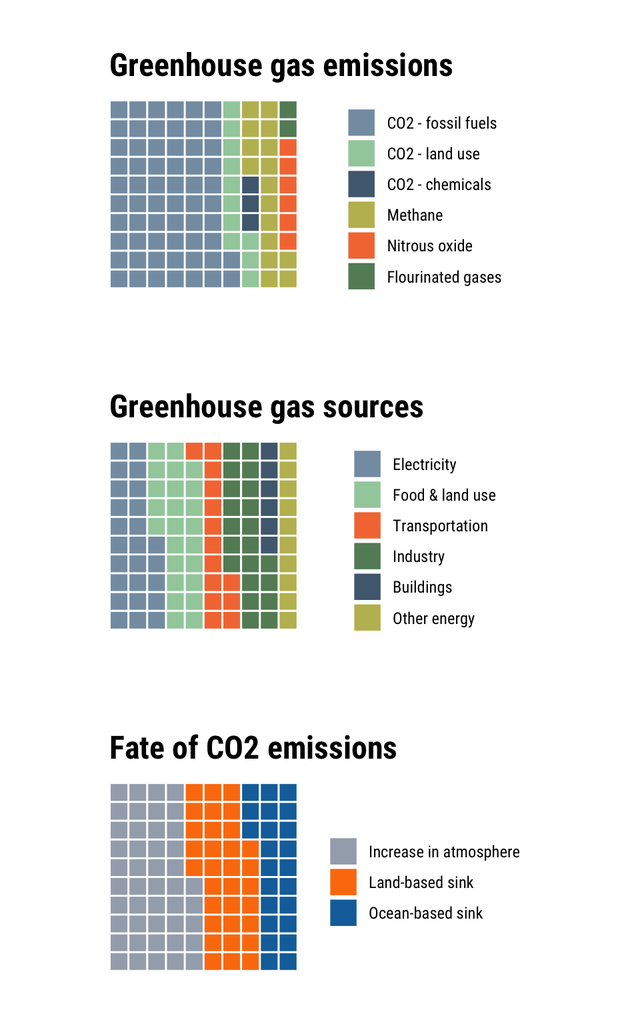

```r
library(hrbrthemes)
library(waffle)

## data frame of GHG data
ghg <- tibble(
  parts = as.factor(c("CO2 - fossil fuels", "CO2 - land use", "CO2 - chemicals",
                      "Methane", "Nitrous oxide", "Flourinated gases",
                      "Electricity", "Food & land use", "Transportation",
                      "Industry", "Buildings", "Other energy",
                      "Increase in atmosphere", "Land-based sink",
                      "Ocean-based sink")),
  values = c(62, 11, 3, 16, 6, 2, 25, 24, 14, 21, 6, 10, 45, 32, 23),
  category = c(rep("Greenhouse gas emissions", 6),
               rep("Greenhouse gas sources", 6),
               rep("Fate of CO2 emissions", 3))
)

## Greenhouse gas emissions
ghg_1 <- filter(ghg, category == "Greenhouse gas emissions")
ghg_p1 <- ggplot(ghg_1,
                 aes(fill=parts, values=values)) +
  geom_waffle(color = "white", size = 0.5, n_rows = 10) +
  scale_x_discrete(expand=c(0,0)) +
  scale_y_discrete(expand=c(0,0)) +
  ggthemes::scale_fill_tableau(name=NULL,
                               palette = "Miller Stone",
                               type = "regular",
                               direction = 1,
                               breaks = ghg_1$parts) +
  coord_equal() +
  labs(
    title = unique(ghg_1$category)
  ) +
  theme_ipsum_rc(grid="") +
  theme_enhance_waffle()

## Greenhouse gas sources
ghg_2 <- filter(ghg, category == "Greenhouse gas sources")
ghg_p2 <- ggplot(ghg_2,
                 aes(fill=parts, values=values)) +
  geom_waffle(color = "white", size = 0.5, n_rows = 10) +
  scale_x_discrete(expand=c(0,0)) +
  scale_y_discrete(expand=c(0,0)) +
  ggthemes::scale_fill_tableau(name=NULL,
                               palette = "Miller Stone",
                               type = "regular",
                               direction = 1,
                               breaks = ghg_2$parts) +
  coord_equal() +
  labs(
    title = unique(ghg_2$category)
  ) +
  theme_ipsum_rc(grid="") +
  theme_enhance_waffle()

## Fate of CO2 emissions
ghg_3 <- filter(ghg, category == "Fate of CO2 emissions")
ghg_p3 <- ggplot(ghg_3,
                 aes(fill=parts, values=values)) +
  geom_waffle(color = "white", size = 0.5, n_rows = 10) +
  scale_x_discrete(expand=c(0,0)) +
  scale_y_discrete(expand=c(0,0)) +
  ggthemes::scale_fill_tableau(name = NULL,
                               palette = "Color Blind",
                               type = "regular",
                               direction = -1,
                               breaks = ghg_3$parts) +
  coord_equal() +
  labs(
    title = unique(ghg_3$category)
  ) +
  theme_ipsum_rc(grid="") +
  theme_enhance_waffle()

## stick the plots together
iron(ghg_p1, ghg_p2, ghg_p3)
```